# E_News_Express_Project

### Business Statistics - E-news Express Project

### Description

#### Business Context

The advent of e-news, or electronic news, portals has offered us a great opportunity to quickly get updates on the day-to-day events occurring globally. The information on these portals is retrieved electronically from online databases, processed using a variety of software, and then transmitted to the users. There are multiple advantages of transmitting news electronically, like faster access to the content and the ability to utilize different technologies such as audio, graphics, video, and other interactive elements that are either not being used or aren’t common yet in traditional newspapers.

E-news Express, an online news portal, aims to expand its business by acquiring new subscribers. With every visitor to the website taking certain actions based on their interest, the company plans to analyze these actions to understand user interests and determine how to drive better engagement. The executives at E-news Express believe that there has been a decline in new monthly subscribers compared to the past year because the current webpage is not designed well enough in terms of the outline & recommended content to keep customers engaged long enough to decide to subscribe.

[Companies often analyze user responses to two variants of a product to decide which of the two variants is more effective. This experimental technique, known as A/B testing, is used to determine whether a new feature attracts users based on a chosen metric.]

#### Objective

The design team of the company has researched and created a new landing page that has a new outline & more relevant content compared to the old page. To test the effectiveness of the new landing page in gathering new subscribers, the Data Science team experimented by randomly selecting 100 users and dividing them equally into two groups. The existing landing page was served to the first group (control group) and the new landing page to the second group (treatment group). Data regarding the interaction of users in both groups with the two versions of the landing page was collected. Being a data scientist in E-news Express, you have been asked to explore the data and perform a statistical analysis (at a significance level of 5%) to determine the effectiveness of the new landing page in gathering new subscribers for the news portal by answering the following questions:

1. Do the users spend more time on the new landing page than on the existing landing page?
2. Is the conversion rate (the proportion of users who visit the landing page and get converted) for the new page greater than the conversion rate for the old page?
3. Does the converted status depend on the preferred language?
4. Is the time spent on the new page the same for the different language users?

#### Data Dictionary

The data contains information regarding the interaction of users in both groups with the two versions of the landing page.

- user_id - Unique user ID of the person visiting the website
- group - Whether the user belongs to the first group (control) or the second group (treatment)
- landing_page - Whether the landing page is new or old
- time_spent_on_the_page - Time (in minutes) spent by the user on the landing page
- converted - Whether the user gets converted to a subscriber of the news portal or not
- language_preferred - language chosen by the user to view the landing page

Import all the necessary libraries

```python
import pandas as pd
import numpy as np
import matplotlib.pyplot as plt
import seaborn as sns
%matplotlib inline
import scipy.stats as stats
```

Load the dataset

```python
df = pd.read_csv('/content/abtest.csv')
```

### Explore the dataset and extract insights using Exploratory Data Analysis.

#### Understanding the structure of the data.

```python
df.head()
```

|  | user_id | group | landing_page | time_spent_on_the_page | converted | language_preferred |
| --- | --- | --- | --- | --- | --- | --- |
| 0 | 546592 | control | old | 3.48 | no | Spanish |
| 1 | 546468 | treatment | new | 7.13 | yes | English |
| 2 | 546462 | treatment | new | 4.40 | no | Spanish |
| 3 | 546567 | control | old | 3.02 | no | French |
| 4 | 546459 | treatment | new | 4.75 | yes | Spanish |

```python
df.tail()
```

|  | user_id | group | landing_page | time_spent_on_the_page | converted | language_preferred |
| --- | --- | --- | --- | --- | --- | --- |
| 95 | 546446 | treatment | new | 5.15 | no | Spanish |
| 96 | 546544 | control | old | 6.52 | yes | English |
| 97 | 546472 | treatment | new | 7.07 | yes | Spanish |
| 98 | 546481 | treatment | new | 6.20 | yes | Spanish |
| 99 | 546483 | treatment | new | 5.86 | yes | English |

#### Observations

- Each row represents the interaction of users in the Control and Treatment group for the different versions of the landing page ( Old and New ).

```python
df.shape
```

```
(100, 6)
```

#### Observations

- There are 100 rows and 6 columns are present in the abtest datset.

```python
df.isnull().sum()
```

|  | 0 |
| --- | --- |
| user_id | 0 |
| group | 0 |
| landing_page | 0 |
| time_spent_on_the_page | 0 |
| converted | 0 |
| language_preferred | 0 |

**dtype:** int64

#### Observations:

- There are no null values in this dataset.

```python
df.info()
```

```
<class 'pandas.core.frame.DataFrame'>
RangeIndex: 100 entries, 0 to 99
Data columns (total 6 columns):
 #   Column                  Non-Null Count  Dtype
---  ------                  --------------  -----
 0   user_id                 100 non-null    int64
 1   group                   100 non-null    object
 2   landing_page            100 non-null    object
 3   time_spent_on_the_page  100 non-null    float64
 4   converted               100 non-null    object
 5   language_preferred      100 non-null    object
dtypes: float64(1), int64(1), object(4)
memory usage: 4.8+ KB
```

#### Observations

There are different data types in this dataset:

- User_id is an integer type variable
- time_spent_on_the_page is a float type variable
- The 4 object variables are group, landing_page, converted, and language_preffered

```python
df.describe()
```

|  | user_id | time_spent_on_the_page |
| --- | --- | --- |
| count | 100.000000 | 100.000000 |
| mean | 546517.000000 | 5.377800 |
| std | 52.295779 | 2.378166 |
| min | 546443.000000 | 0.190000 |
| 25% | 546467.750000 | 3.880000 |
| 50% | 546492.500000 | 5.415000 |
| 75% | 546567.250000 | 7.022500 |
| max | 546592.000000 | 10.710000 |

#### Observations:

- The statistical summary for the numerical variables.
- The average time spent on the page is about 5.38 minutes with a standard deviation of 2.38 minutes.
- 50% of the entries spent about 5.42 minutes on the page.
- The minimum time spent on the page was 0.19 minutes and the maximum time spent on the page was 10.71 minutes.

```python
df.describe(include = 'object')
```

|  | group | landing_page | converted | language_preferred |
| --- | --- | --- | --- | --- |
| count | 100 | 100 | 100 | 100 |
| unique | 2 | 2 | 2 | 3 |
| top | control | old | yes | Spanish |
| freq | 50 | 50 | 54 | 34 |

```python
df['group'].value_counts()
```

| group | count |
| --- | --- |
| control | 50 |
| treatment | 50 |

**dtype:** int64

```python
df['landing_page'].value_counts()
```

| landing_page | count |
| --- | --- |
| old | 50 |
| new | 50 |

**dtype:** int64

```python
df['converted'].value_counts()
```

| converted | count |
| --- | --- |
| yes | 54 |
| no | 46 |

**dtype:** int64

```python
df['language_preferred'].value_counts()
```

| language_preferred | count |
| --- | --- |
| Spanish | 34 |
| French | 34 |
| English | 32 |

**dtype:** int64

#### Observations

- The caegorical variables have a 100 entries.
- The group variable has two unique values, control and treatment, with 50 entries each.
- The landing_page variable has two unique values, old and new, with 50 entries each.
- The converted variable has two unique values, yes and no, with 54 and 46 entries respectively.
- The language_preferred variable has three unique values:

  Spanish, French, English.

  They have 34, 34, and 32 entries respectively

#### Univariate Analysis

Time spend on page

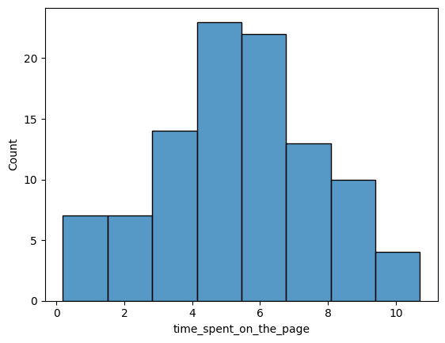

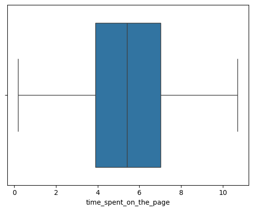

```python
sns.histplot(data=df,x='time_spent_on_the_page')
plt.show()
sns.boxplot(data=df,x='time_spent_on_the_page')
plt.show()
```

Observations:

- The time spent on the page appears to be normally distributed.
- There are no outliers in time spent on the page.

Group

```python
df['group'].value_counts()
```

| group | count |
| --- | --- |
| control | 50 |
| treatment | 50 |

**dtype:** int64

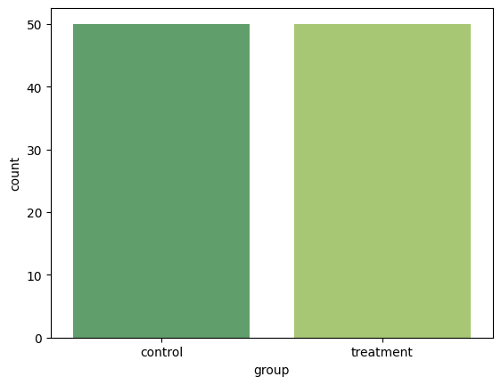

```python
sns.countplot(data=df, x='group', hue='group', palette='summer', dodge=False, legend=False)
plt.show()
```

Observations:

- It appears that the sample is equally split amongst the control and treatment groups

Landing page

```python
df['landing_page'].value_counts()
```

| landing_page | count |
| --- | --- |
| old | 50 |
| new | 50 |

**dtype:** int64

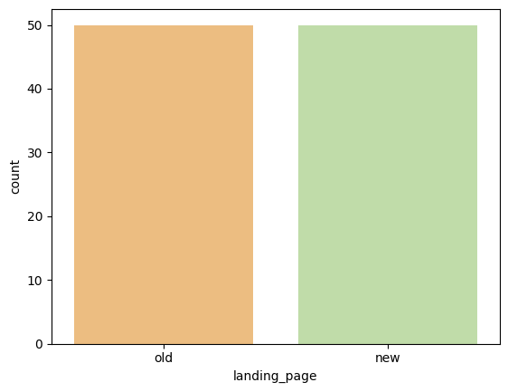

```python
sns.countplot(data=df, x='landing_page', hue='landing_page', palette='Spectral', dodge=False, legend=False)
plt.show()
```

Observations:

- It appears that the sample is equally split amongst the old and new landing pages.

Converted

```python
df['converted'].value_counts()
```

| converted | count |
| --- | --- |
| yes | 54 |
| no | 46 |

**dtype:** int64

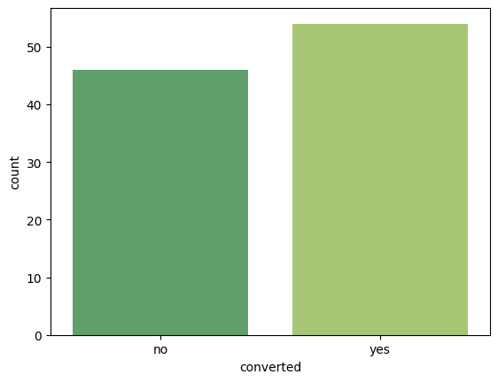

```python
sns.countplot(data=df, x='converted', hue='converted', palette='summer', dodge=False, legend=False)
plt.show()
```

Observations:

- It appears that there are more people who converted to the new lading page opposed to the the people who did not convert.

Language preferred

```python
df['language_preferred'].value_counts()
```

| language_preferred | count |
| --- | --- |
| Spanish | 34 |
| French | 34 |
| English | 32 |

**dtype:** int64

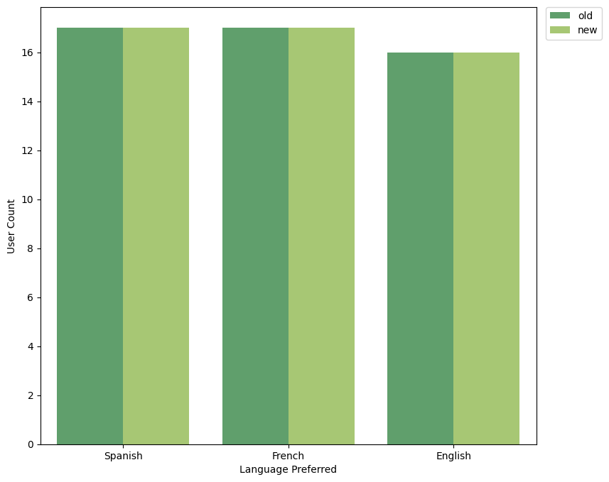

```python
plt.figure(figsize=(9, 8))
plot = sns.countplot(data=df, x ='language_preferred',hue='landing_page',palette='summer',order=df['language_preferred'].value_counts().index)
plt.legend(bbox_to_anchor=(1.02, 1), loc='upper left', borderaxespad=0)
plt.xlabel('Language Preferred')
plt.ylabel('User Count')
plt.show()
```

Observations:

- It appears that Spanish and French had the most amount of entries with 34 each and English had the least amount of entries with 32.
- There are 3 unique languages( Spanish,English and French) preferred by the users to read the old and new landing pages

#### Bivariate Analysis

Landing Page vs Time Spent on the Page

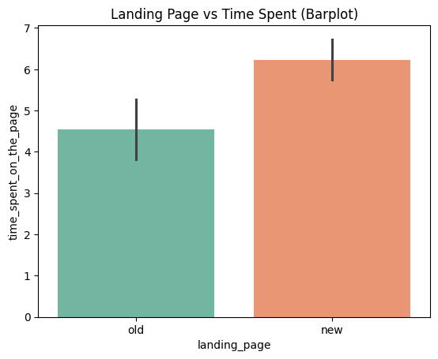

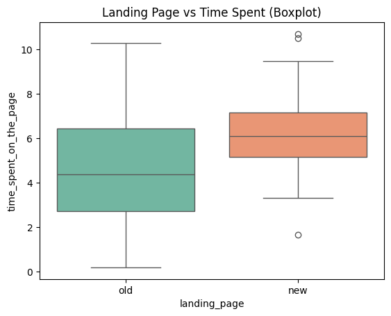

```python
sns.barplot(data=df, x='landing_page', y='time_spent_on_the_page', hue='landing_page', palette= 'Set2')
plt.title('Landing Page vs Time Spent (Barplot)')
plt.show()
sns.boxplot(data=df, x='landing_page', y='time_spent_on_the_page', hue='landing_page', palette= 'Set2')
plt.title('Landing Page vs Time Spent (Boxplot)')
plt.show()
```

Observations

- The average time spent by visitors who got converted to subscribers is around 6-7 minutes for both landing pages.
- Users appear to spend more time on the new landing page comapared to the old lading page.

Language Preferred vs Time Spent on the page

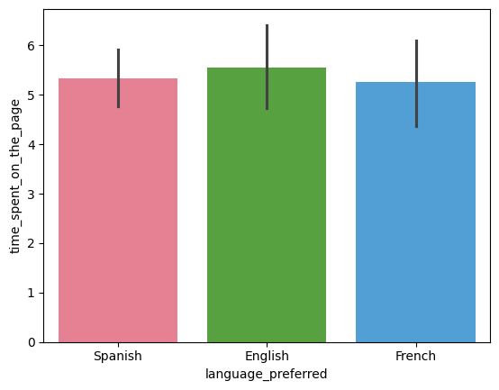

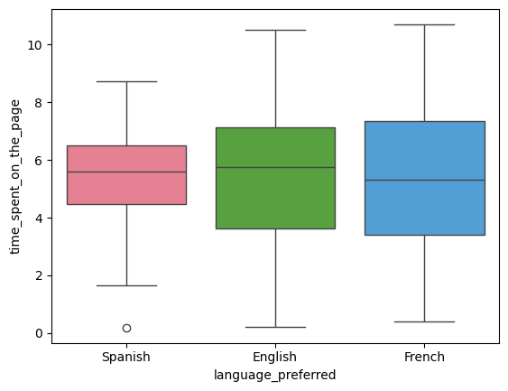

```python
sns.barplot(data = df, x ='language_preferred', y ='time_spent_on_the_page', hue='language_preferred', palette= 'husl')
plt.show()
sns.boxplot(data = df, x ='language_preferred', y ='time_spent_on_the_page',hue='language_preferred', palette= 'husl')
plt.show()
```

Observations:

- Box plot corresponding to the Spanish language indicates the presence of outliers and its box plot area is narrowest indicating low variability in data.
- The average time spent on the page appears to be similar for all the preferred languages. However, users who preferred Spanish appear to have the smallest spread in time spent on the page.

Converted Vs Time Spent on the Landing Page

```python
df.groupby(['converted'])['time_spent_on_the_page'].mean()
```

| converted | time_spent_on_the_page |
| --- | --- |
| no | 3.915870 |
| yes | 6.623148 |

**dtype:** float64

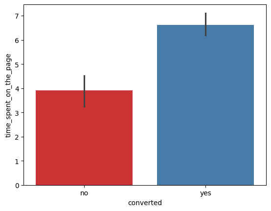

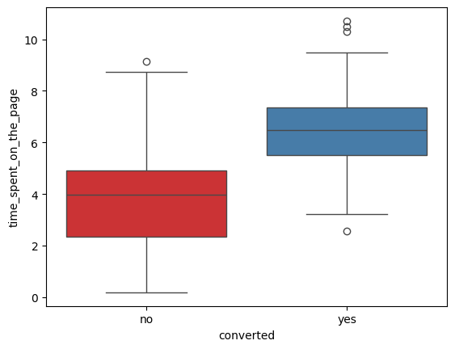

```python
sns.barplot(data = df, x = 'converted', y = 'time_spent_on_the_page',hue='converted', palette= 'Set1')
plt.show()
sns.boxplot(data = df, x = 'converted', y = 'time_spent_on_the_page',hue='converted', palette= 'Set1')
plt.show()
```

Observations:

- The average time spent by users who got converted to subscribers on the old page and the new page is around 6 to 7 minutes.
- The box plot for the users who got converted indicates a high average time spent on the page compared to the users who did not get converted to subscribers.
- Box plots of both conversion status indicate presence of outliers.

Relationship between preferred language, conversion status, and landing page

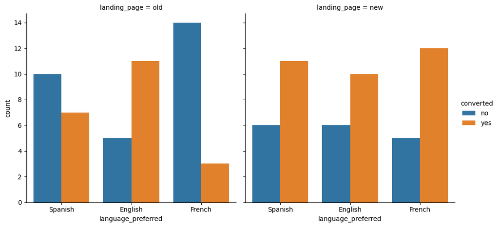

```python
sns.catplot(data = df, x = 'language_preferred', hue = 'converted', col = 'landing_page', kind = 'count');
```

Observations:

- It appears that users that preferreed Spanish and French opted not to convert to a subscriber when viewing the old landing page.
- The users of all language preferences converted to subscribers when viewing the new landing page.

### 1. Do the users spend more time on the new landing page than the old landing page?

#### Perform Visual Analysis

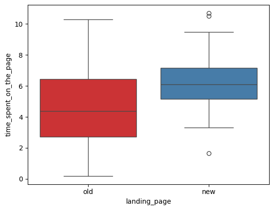

```python
sns.boxplot(x = 'landing_page', y = 'time_spent_on_the_page', data = df,hue='landing_page', palette= 'Set1')
plt.show()
```

Observations:

- The average time spent on the new page seems greater than the old page.

#### Step 1: Define the null and alternate hypotheses

The null and alternative hypotheses can be formulated as:

$H_0$ The mean time spent on the new landing page is less than or equal to the mean time spent on the old landing page.

$H_a$ The mean time spent by the users on the new page is greater than the mean time spent by the users on the old page.

Let μ1 and μ2 be the mean time spent on the new landing page and the mean time spent on the old landing page

Mathematically, the above-formulated hypotheses can be written as:

$H_0$ : μ1<=μ2

Alternate hypothesis

#### Step 3: Decide the significance level

As given in the problem statement, we select $\alpha = 0.05$.

#### Step 4: Collect and prepare data

```python
# create subsetted data frame for new landing page users
time_spent_new = df[df['landing_page'] == 'new']['time_spent_on_the_page']

# create subsetted data frame for old landing page users
time_spent_old = df[df['landing_page'] == 'old']['time_spent_on_the_page']
```

```python
print('The sample standard deviation of the time spent on the new page is:', round(time_spent_new.std(),2))
print('The sample standard deviation of the time spent on the old page is:', round(time_spent_old.std(),2))
```

```
The sample standard deviation of the time spent on the new page is: 1.82
The sample standard deviation of the time spent on the old page is: 2.58
```

Based on the sample standard deviations of the two groups, the population standard deviations can be assumed to be unequal.

Two-sample independent t-test assumptions:

- Continuous data - Yes, the time spent on the pages is measured on a continuous scale.
- Normally distributed populations - Yes, we are informed that the populations are assumed to be normal.
- Independent populations - As we are taking random samples for two different groups, the two samples are from two independent populations.
- Unequal population standard deviations - As the sample standard deviations are different, the population standard deviations may be assumed to be different.
- Random sampling from the population - Yes, we are informed that the collected sample a simple random sample.

All Assumptions are satisfied. We can use two sample T-test for this problem.

#### Step 5: Calculate the p-value

```python
from scipy.stats import ttest_ind

test_stat, p_value =  ttest_ind(time_spent_new, time_spent_old, equal_var = False, alternative = 'greater')

print('The p-value is', p_value)
```

```
The p-value is 0.0001392381225166549
```

#### Step 6: Compare the p-value with $\alpha$

```python
if p_value < 0.05:
    print(f'As the p-value {p_value} is less than the level of significance, we reject the null hypothesis.')
else:
    print(f'As the p-value {p_value} is greater than the level of significance, we fail to reject the null hypothesis.')
```

```
As the p-value 0.0001392381225166549 is less than the level of significance, we reject the null hypothesis.
```

#### Step 7: Draw inference

- The p-value (~0.0001) is less than the level of significance (0.05) and we, therefore, reject the null hypothesis.
- At a 5% significance level, we conclude that we have enough statistical evidence to say that users spend more time on the new landing page than on the existing landing page.

### 2. Is the conversion rate (the proportion of users who visit the landing page and get converted) for the new page greater than the conversion rate for the old page?

#### Perform Visual Analysis

```python
pd.crosstab(df['landing_page'],df['converted'])
```

| converted landing_page | no | yes |
| --- | --- | --- |
| new | 17 | 33 |
| old | 29 | 21 |

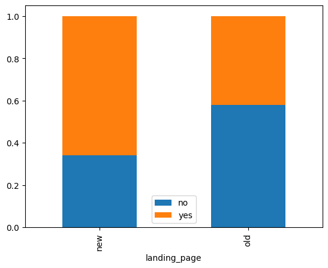

```python
pd.crosstab(df['landing_page'],df['converted'],normalize='index').plot(kind="bar",stacked=True)
plt.legend()
plt.show()
```

Observations:

- It appears users on the new landing page are more likely to convert to subscribers than users on the old landing page.

#### Step 1: Define the null and alternate hypotheses

$H_0$ : The conversion rate of the new page is equal to the conversion rate of the old page.

$H_a$ : The conversion rate of the new page is greater than the conversion rate of the old page.

Let p1, and p2 be the proportions of converters in the new landing page and old landing page respectively.

Mathematically, the above-formulated hypotheses can be written as:

$H_0$ : p1<=p2

against the alternate hypothesis

$H_a$ : p1>p2

#### Step 2: Select Appropriate test

- This is a one-tailed test concerning two population proportions from two independent populations.
- A Two Proportions Z-Test would be the appropriate test to perform.

#### Step 3: Decide the significance level

As given in the problem statement, we select α = 0.05.

#### Step 4: Collect and prepare data

```python
new_converted = df[df['group'] == 'treatment']['converted'].value_counts()['yes']
old_converted = df[df['group'] == 'control']['converted'].value_counts()['yes']

n_treatment = df.group.value_counts()['treatment']
n_control = df.group.value_counts()['control']

print('The numbers of users served the new and old pages are {0} and {1} respectively'.format(n_control, n_treatment ))
```

```
The numbers of users served the new and old pages are 50 and 50 respectively
```

Two-proportion z-test assumptions:

- Binomally distributed population - Yes, a user is either converted or not converted.
- Random sampling from the population - Yes, we are informed that the collected sample is a simple random sample.
- Can the binomial distribution approximated to normal distribution - Yes.

All the assumptions are satisfied, we can use z -test for this problem.

#### Step 5: Calculate the p-value

```python
from statsmodels.stats.proportion import proportions_ztest

test_stat, p_value = proportions_ztest([new_converted, old_converted] , [n_treatment, n_control], alternative ='larger')

print('The p-value is', p_value)
```

```
The p-value is 0.008026308204056278
```

#### Step 6: Compare the p-value with $\alpha$

```python
if p_value < 0.05:
    print(f'As the p-value {p_value} is less than the level of significance, we reject the null hypothesis.')
else:
    print(f'As the p-value {p_value} is greater than the level of significance, we fail to reject the null hypothesis.')
```

```
As the p-value 0.008026308204056278 is less than the level of significance, we reject the null hypothesis.
```

#### Step 7: Draw inference

- Since the p-value is much less than the level of significance at 5%, the null hypothesis is rejected.
- This means that their is significant evidence that the conversion rate of the new page is greater than the conversion rate of the old page.

### 3. Is the conversion status and preferred language independent or related?

#### Perform Visual Analysis

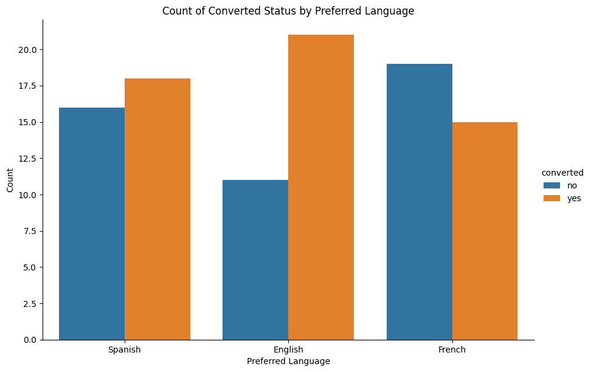

```python
sns.catplot(x='language_preferred', hue='converted', kind='count', data=df, height=6, aspect=1.5)
plt.title('Count of Converted Status by Preferred Language')
plt.xlabel('Preferred Language')
plt.ylabel('Count')
plt.show()
```

Observations

- English has the highest conversion rate followed by Spanish and French.

#### Step 1: Define the null and alternate hypotheses

The null and alternative hypotheses can be formulated as:

$H_0$ : The Converted status is independent of language preferred.

$H_a$ : The Converted status is NOT independent of language preferred.

#### Step 2: Select Appropriate test

- The test is concerned with the relationship of two categorical variables, Converted and Language preferred.
- A Chi-square test of independence would be an appropriate test to perform.

#### Step 3: Decide the significance level

As given in the problem statement, we select $\alpha = 0.05$.

#### Step 4: Collect and prepare data

```python
contingency_table = pd.crosstab(df['language_preferred'], df['converted'])

contingency_table
```

| converted language_preferred | no | yes |
| --- | --- | --- |
| English | 11 | 21 |
| French | 19 | 15 |
| Spanish | 16 | 18 |

Chi-Squared test for independence assumptions:

- Categorical variables - Yes
- Expected value of the number of sample observations in each level of the variable is at least 5 - Yes, the number of observations in each level is greater than 5.
- Random sampling from the population - Yes, we are informed that the collected sample is a simple random sample.

All the assumptions are satisfied, we can use the Chi-square test of independence for this problem.

#### Step 5: Calculate the p-value

```python
from scipy.stats import chi2_contingency

chi2, p_value, dof, exp_freq = chi2_contingency(contingency_table)

print('The p-value is', p_value)
```

```
The p-value is 0.2129888748754345
```

#### Step 6: Compare the p-value with $α$

```python
if p_value < 0.05:
    print(f'As the p-value {p_value} is less than the level of significance, we reject the null hypothesis.')
else:
    print(f'As the p-value {p_value} is greater than the level of significance, we fail to reject the null hypothesis.')
```

```
As the p-value 0.2129888748754345 is greater than the level of significance, we fail to reject the null hypothesis.
```

### 4. Is the time spent on the new page same for the different language users?

#### Perform Visual Analysis

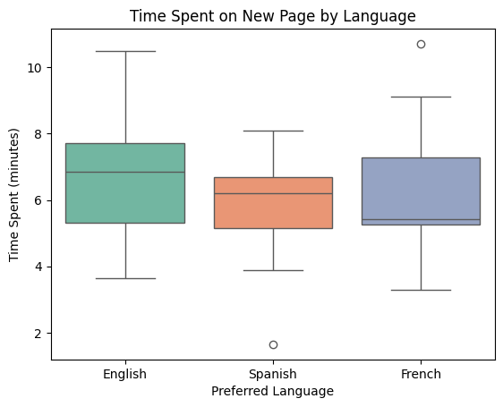

```python
sns.boxplot(x='language_preferred', y='time_spent_on_the_page', hue='language_preferred',data=df[df['landing_page'] == 'new'], palette='Set2')
plt.title('Time Spent on New Page by Language')
plt.xlabel('Preferred Language')
plt.ylabel('Time Spent (minutes)')
plt.show()
```

Observations

- The average time spent on the landing page is almost equal for all three languages.
- The variation in the time spent by the English users is more, and the Spanish users are about slightly more consistent in engagement.
- Oultiers are spotted for Spanish and French.

```python
mean_time_spent = df[df['landing_page'] == 'new'].groupby('language_preferred')['time_spent_on_the_page'].mean()
```

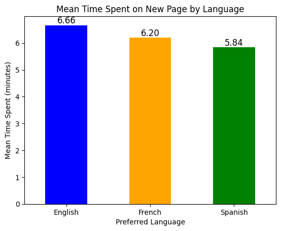

```python
ax = mean_time_spent.plot(kind='bar', color = ['Blue','Orange','Green'])
plt.title('Mean Time Spent on New Page by Language')
plt.xlabel('Preferred Language')
plt.ylabel('Mean Time Spent (minutes)')
plt.xticks(rotation=0)
for p in ax.patches:
    ax.annotate(f'{p.get_height():.2f}', (p.get_x() + p.get_width() / 2., p.get_height()),
                ha='center', va='bottom', fontsize=12, color='black')

plt.show()
```

Observations:

The mean time spent on the new page for different language users:

- In English language 6.66 mean time spent on the new page.
- In French language 6.20 mean time spent on the new page.
- In Spanish language 5.84 mean time spent on the new page.

#### Step 1: Define the null and alternate hypotheses

$H_0$ : The mean time spent on the new lading page is the same across all preferred langauges.

$H_a$ : At least one of the mean times spent on the new landing page is different amongst the preferred languages.

Let $\mu_1$,$\mu_2$,$\mu_3$ be the means of time spent on the new landing page for language preferences Spanish, French, and English respectively.

Mathematically, the above-formulated hypotheses can be written as:

$H_0$ : $\mu_1$= $\mu_2$ = $\mu_3$.

$H_a$ : At least one-time average of the new landing page is different among the language preferences.

#### Step 2: Select Appropriate test

- This is a problem, concerning three population means.
- Based on this information, a One-way ANOVA F-test would be an appropriate test to perform.

#### Step 3: Decide the significance level

As given in the problem statement, we select $\alpha =0.05$.

#### Step 4: Collect and prepare data

Shapiro-Wilk’s test

We will test the null hypothesis

$H_0$ : Time spent on the landing page follows a normal distribution

$H_a$ : Time spent on the landing page does not follow a normal distribution

```python
from scipy import stats
statistic, p_value  = stats.shapiro(df[df['landing_page']=='new']['time_spent_on_the_page'])
print('The p-value is', p_value)
```

```
The p-value is 0.8040040364746845
```

Observations:

- The p-value (~0.804) is greater than the level of significance (0.05) and we, therefore, fail to reject the null hypothesis.
- At a 5% significance level, we conclude that time spent on the landing page follows a normal distribution.

Levene’s test

We will test the null hypothesis

$H_0$ : All the population variances are equal

against the alternative hypothesis

$H_a$ : At least one variance is different from the rest

```python
from scipy.stats import levene
statistic, p_value = levene(df[(df['landing_page'] == 'new') & (df['language_preferred'] == 'Spanish')]['time_spent_on_the_page'],
                            df[(df['landing_page'] == 'new') & (df['language_preferred'] == 'French')]['time_spent_on_the_page'],
                            df[(df['landing_page'] == 'new') & (df['language_preferred'] == 'English')]['time_spent_on_the_page'])
print('The p-value is', p_value)
```

```
The p-value is 0.46711357711340173
```

Observations:

- The p-value (~0.46) is greater than the level of significance (0.05) and we, therefore, fail to reject the null hypothesis.
- At a 5% significance level, we conclude that variances of all the variables are equal.

One-way ANOVA test assumptions:

- The populations are normally distributed - Yes, the normality assumption is verified using the Shapiro-Wilk’s test.
- Samples are independent simple random samples - Yes, we are informed that the collected sample is a simple random sample.
- Population variances are equal - Yes, the homogeneity of variance assumption is verified using the Levene's test.

All our assumptions are satisfied. We can use One-way ANOVA F-test for this problem.

#### Step 5: Calculate the p-value

```python
from scipy.stats import f_oneway

test_stat, p_value = f_oneway(df[(df['landing_page'] == 'new') & (df['language_preferred'] == 'Spanish')]['time_spent_on_the_page'],
                              df[(df['landing_page'] == 'new') & (df['language_preferred'] == 'French')]['time_spent_on_the_page'],
                              df[(df['landing_page'] == 'new') & (df['language_preferred'] == 'English')]['time_spent_on_the_page'])
print('The p-value is ' + str(p_value))
```

```
The p-value is 0.43204138694325955
```

#### Step 6: Compare the p-value with $\alpha$

```python
if p_value < 0.05:
    print(f'As the p-value {p_value} is less than the level of significance, we reject the null hypothesis.')
else:
    print(f'As the p-value {p_value} is greater than the level of significance, we fail to reject the null hypothesis.')
```

```
As the p-value 0.43204138694325955 is greater than the level of significance, we fail to reject the null hypothesis.
```

#### Step 7: Draw inference

- The p-value (~0.43) is greater than the level of significance (0.05) and we, therefore, fail to reject the null hypothesis.
- At a 5% significance level, we conclude that the mean time spent on the new landing page for all three languages are all equal.

### Conclusion and Business Recommendations

#### Conclusion

- New landing page attracts more time, which means there is more engagement from the users.
- The conversion rate for a new landing page is much higher.
- Conversion status is independent of preferred language, suggesting consistent performance across languages.
- Time spent is consistent across language groups, showing uniform user experience.

#### Business Recommendations

- Fully implement the new landing page due to increased engagement and conversions.
- Content personalization by language for better improvement in engagement and conversion.
- Continuously perform A/B testing to refine and optimize the landing page.
- Focus on user feedback to identify additional improvements for enhancing user experience.